# Chapter-8-ExerciseSolutions

2022-11-02

```r
head(hl)
```

```
##    ofp ofnp opp opnp emr hosp exclhlth poorhlth numchron adldiff noreast
## 1:   5    0   0    0   0    1        0        0        2       0       0
## 2:   1    0   2    0   2    0        0        0        2       0       0
## 3:  13    0   0    0   3    3        0        1        4       1       0
## 4:  16    0   5    0   1    1        0        1        2       1       0
## 5:   3    0   0    0   0    0        0        0        2       1       0
## 6:  17    0   0    0   0    0        0        1        5       1       0
##    midwest west age black male married school faminc employed privins medicaid
## 1:       0    0 6.9     1    1       1      6 2.8810        1       1        0
## 2:       0    0 7.4     0    0       1     10 2.7478        0       1        0
## 3:       0    0 6.6     1    0       0     10 0.6532        0       0        1
## 4:       0    0 7.6     0    1       1      3 0.6588        0       1        0
## 5:       0    0 7.9     0    0       1      6 0.6588        0       1        0
## 6:       0    0 6.6     0    0       0      7 0.3301        0       0        1
```

1. There is a variable called faminc, which indicates the income of the family. Conduct a test for the median value of 1.75.
2. Null Hypothesis :the median value is 1.75
3. Since the family income values are numerical, we will assume they follow N(μ,σ) Since a normal distribution is always symmetric about the mean, its median value will be the same as its mean.

```r
print(paste("Median:",median(hl$faminc)))
```

```
## [1] "Median: 1.69815"
```

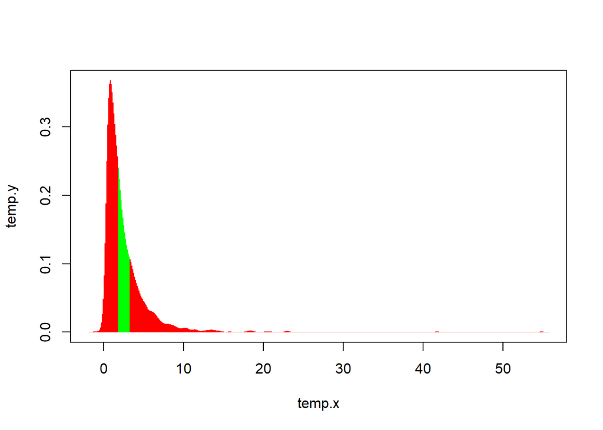

```
## [1] 0.7476169
```

```r
p_2tail(hl$faminc, 1.75)
```

p-value is largely above the threshold of 0.05, so the null hypothesis cannot be rejected.

There is a variable called age. Assuming this follows an exponential distribution, test the hypothesis that the mean value of age is 7.5.

Null Hypothesis :the meean value is 7.5

Since the age values are numerical, we will assume they follow N(μ,σ) Since a normal distribution is always symmetric about the mean, its median value will be the same as its mean.

```r
print(paste("Median:",median(hl$age)))
```

```
## [1] "Median: 7.3"
```

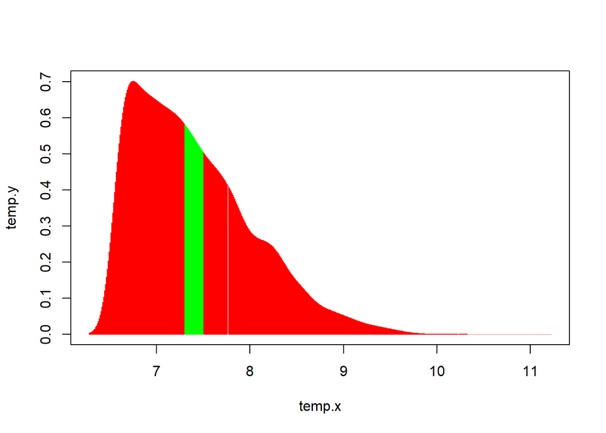

```
## [1] 0.894916
```

```r
p_2tail(hl$age, 7.5)
```

There are two variables named males and exclhlth. The first one refers to gender and the second to the health condition. Both variables have only two values 0 or 1. Conduct (a chi-square) test to see if these two variables are related. Note that the null hypothesis is that there is no relationship between the two.

Null Hypothesis : there is no relationship between gender and health variables.

```r
table(hl[, .(male, exclhlth)])
```

```
##     exclhlth
## male    0    1
##    0 2435  193
##    1 1628  150
```

```r
chisq.test(hl$male, hl$exclhlth)
```

```
##
##  Pearson's Chi-squared test with Yates' continuity correction
##
## data:  hl$male and hl$exclhlth
## X-squared = 1.6142, df = 1, p-value = 0.2039
```

```r
head(cars)
```

```
##    Price Age Mileage MPG KBB Price CR Reliability Score
## 1: 11858   6    69.7  34     10600                 0.80
## 2:  3092  17   166.7  21      2400                 0.67
## 3: 14300   4    42.3  35     11100                 0.75
## 4: 10942   6    84.4  28      8500                 0.92
## 5: 12968   5    56.6  27     10000                 0.56
## 6:  2369  22   168.2  34      1800                 0.59
```

4. Develop a test to evaluate the hypothesis that the population mean Price is the same as the population median Price. Hint: Assume a normal distribution for the population.

```r
mean(cars$Price)
```

```
## [1] 7095.79
```

```r
median(cars$Price)
```

```
## [1] 5671.5
```

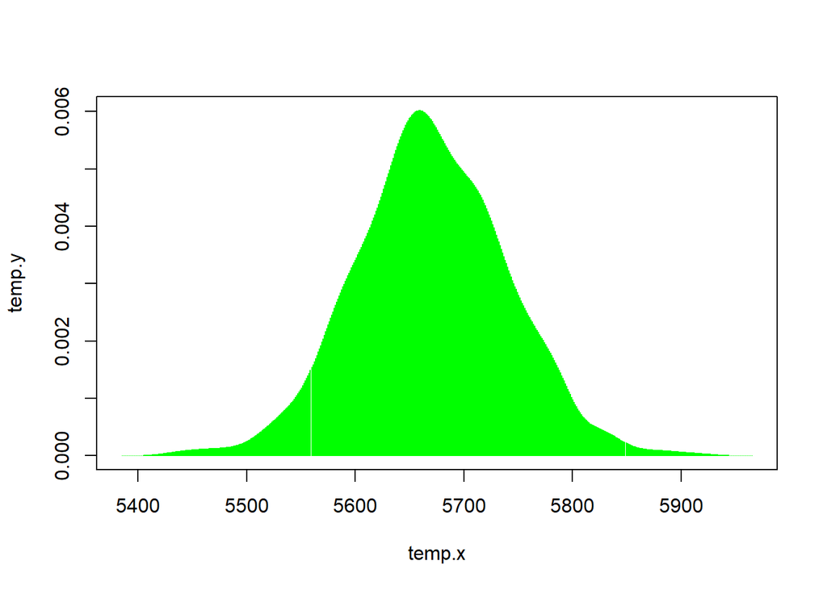

```
## [1] 0
```

```r
sampdist <- vector()

for (i in 1:1000) {
  sampdist <- append(sampdist, mean(rnorm(nrow(cars), mean = median(cars$Price), sd = sd(cars$Price))))
}


p_2tail(sampdist, mean(cars$Price))
```

5. Develop a test to evaluate the hypothesis that the population mean Price is 1.4 times the population standard deviation of Price. Hint: Assume a normal distribution for the population with standard deviation to be the same as the sample and the mean is 1.4 times the sample standard deviation.

```r
mean(cars$Price)
```

```
## [1] 7095.79
```

```r
sd(cars$Price)*1.4
```

```
## [1] 7003.221
```

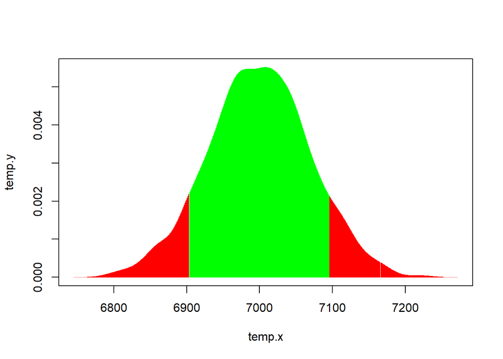

```
## [1] 0.169
```

```r
sampdist <- vector()

for (i in 1:1000) {
  sampdist <- append(sampdist, mean(rnorm(nrow(cars), mean = sd(cars$Price)*1.4, sd = sd(cars$Price))))
}


p_2tail(sampdist, mean(cars$Price))
```

6. Develop a test to evaluate the hypothesis that the population correlation between Age and Mileage is 0.9.

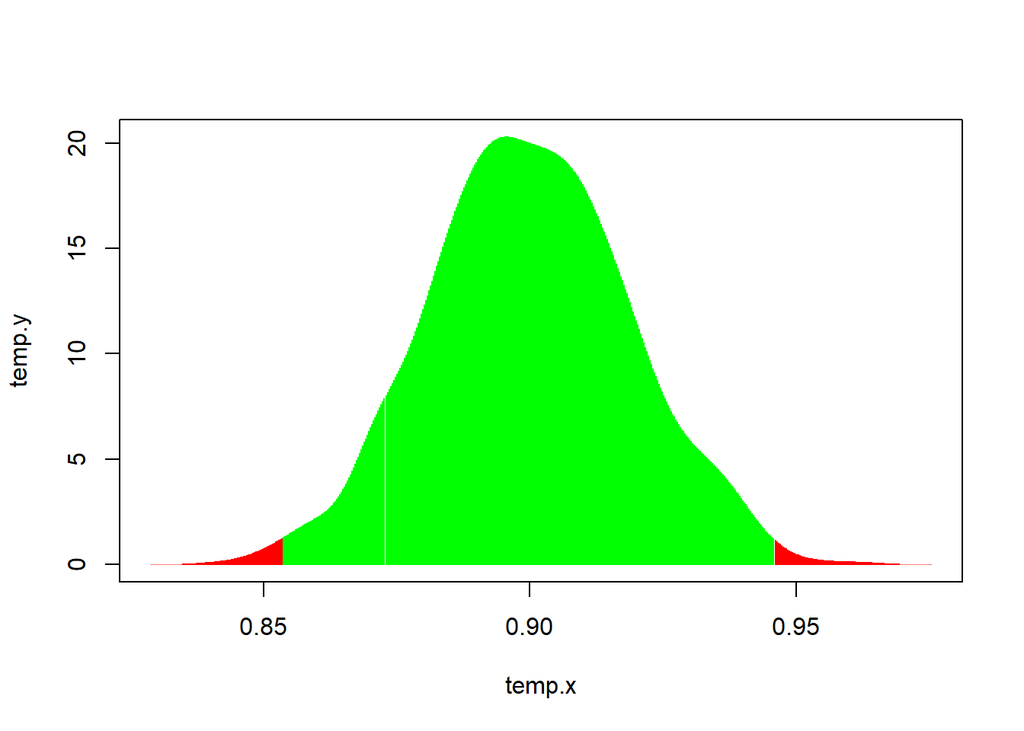

```
## [1] 0.011
```

```r
samp_cor <- vector()

age_sc <- scale(cars$Age)
mil_sc <- scale(cars$Mileage)

for (i in 1:1000) {
  mnd <- MASS::mvrnorm(mu = c(0,0), Sigma = matrix(c(1,0.9,0.9,1), nrow = 2), n = nrow(cars))

  samp_cor <- append(samp_cor,  cov(mnd[,1], mnd[,2]))
}


p_2tail(samp_cor, cor(age_sc, mil_sc)[[1]])
```